# Bikeshare data Project

Adeyinka Abigail Aremo

2/8/2020

```r
library(ggplot2)                     #Calling the ggplot Library
library(dplyr)                       #Calling the dplyr Library
library(lubridate)                   #Calling the lubridate Library
library(tidyr)                       #Calling the tidyr Library

ny = read.csv('new-york-city.csv')
head(ny)
```

```
##         X          Start.Time            End.Time Trip.Duration
## 1 5688089 2017-06-11 14:55:05 2017-06-11 15:08:21           795
## 2 4096714 2017-05-11 15:30:11 2017-05-11 15:41:43           692
## 3 2173887 2017-03-29 13:26:26 2017-03-29 13:48:31          1325
## 4 3945638 2017-05-08 19:47:18 2017-05-08 19:59:01           703
## 5 6208972 2017-06-21 07:49:16 2017-06-21 07:54:46           329
## 6 1285652 2017-02-22 18:55:24 2017-02-22 19:12:03           998
##             Start.Station            End.Station  User.Type Gender Birth.Year
## 1 Suffolk St & Stanton St W Broadway & Spring St Subscriber   Male       1998
## 2 Lexington Ave & E 63 St        1 Ave & E 78 St Subscriber   Male       1981
## 3       1 Pl & Clinton St   Henry St & Degraw St Subscriber   Male       1987
## 4   Barrow St & Hudson St        W 20 St & 8 Ave Subscriber Female       1986
## 5         1 Ave & E 44 St        E 53 St & 3 Ave Subscriber   Male       1992
## 6     State St & Smith St    Bond St & Fulton St Subscriber   Male       1986
```

```r
wash = read.csv('washington.csv')
head(wash)
```

```
##         X          Start.Time            End.Time Trip.Duration
## 1 1621326 2017-06-21 08:36:34 2017-06-21 08:44:43       489.066
## 2  482740 2017-03-11 10:40:00 2017-03-11 10:46:00       402.549
## 3 1330037 2017-05-30 01:02:59 2017-05-30 01:13:37       637.251
## 4  665458 2017-04-02 07:48:35 2017-04-02 08:19:03      1827.341
## 5 1481135 2017-06-10 08:36:28 2017-06-10 09:02:17      1549.427
## 6 1148202 2017-05-14 07:18:18 2017-05-14 07:24:56       398.000
##                                 Start.Station
## 1                        14th & Belmont St NW
## 2                  Yuma St & Tenley Circle NW
## 3              17th St & Massachusetts Ave NW
## 4            Constitution Ave & 2nd St NW/DOL
## 5 Henry Bacon Dr & Lincoln Memorial Circle NW
## 6                               1st & K St SE
##                                           End.Station  User.Type
## 1                                      15th & K St NW Subscriber
## 2                        Connecticut Ave & Yuma St NW Subscriber
## 3                                       5th & K St NW Subscriber
## 4                          M St & Pennsylvania Ave NW   Customer
## 5                               Maine Ave & 7th St SW Subscriber
## 6 Eastern Market Metro / Pennsylvania Ave & 7th St SE Subscriber
```

```r
chi = read.csv('chicago.csv')
head(chi)
```

```
##         X          Start.Time            End.Time Trip.Duration
## 1 1423854 2017-06-23 15:09:32 2017-06-23 15:14:53           321
## 2  955915 2017-05-25 18:19:03 2017-05-25 18:45:53          1610
## 3    9031 2017-01-04 08:27:49 2017-01-04 08:34:45           416
## 4  304487 2017-03-06 13:49:38 2017-03-06 13:55:28           350
## 5   45207 2017-01-17 14:53:07 2017-01-17 15:02:01           534
## 6 1473887 2017-06-26 09:01:20 2017-06-26 09:11:06           586
##                   Start.Station                  End.Station  User.Type Gender
## 1          Wood St & Hubbard St      Damen Ave & Chicago Ave Subscriber   Male
## 2           Theater on the Lake Sheffield Ave & Waveland Ave Subscriber Female
## 3            May St & Taylor St          Wood St & Taylor St Subscriber   Male
## 4 Christiana Ave & Lawrence Ave St. Louis Ave & Balmoral Ave Subscriber   Male
## 5        Clark St & Randolph St Desplaines St & Jackson Blvd Subscriber   Male
## 6  Clinton St & Washington Blvd         Canal St & Taylor St Subscriber   Male
##   Birth.Year
## 1       1992
## 2       1992
## 3       1981
## 4       1986
## 5       1975
## 6       1990
```

#NUMBER 1.TRIP DURATION # Write a function to determine the mean of each dataset trip duration and determine the User types #that accumulately the most trip duration?

```r
#1a. Mean Function
#Writing the Mean Function
mean.function=function(X){      #Writing a mean function
M=sum(X)/length(X)
return(paste('The mean of',M))
}

mean.function(ny$Trip.Duration)   #Mean of New_York_City Bikeshares Trip Duration
```

```
## [1] "The mean of 899.68416"
```

```r
mean.function(wash$Trip.Duration) #Mean of Washigton Bikeshares Trip Duration
```

```
## [1] "The mean of 1237.27995161333"
```

```r
mean.function(chi$Trip.Duration)  #Mean of Chicago Bikeshares Trip Duration
```

```
## [1] "The mean of 936.23929"
```

#NUMBER 1a ANSWER SUMMARY #The mean of New York data trip duration is 899.68. #The mean of Washington data trip duration is 1237.28. #The mean ofChicago data trip duration is 936.24.

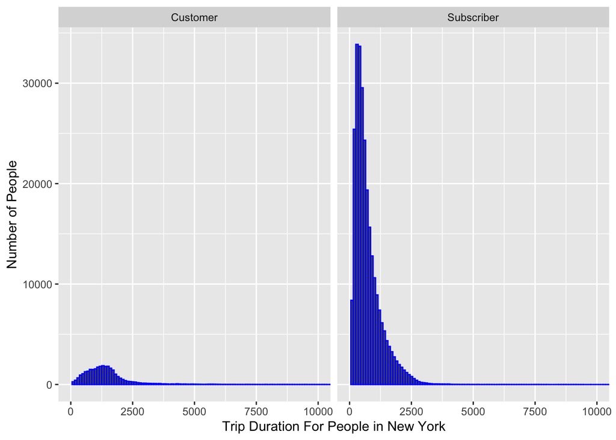

```r
#1b User Tupe that accumulated the most Trip Duration
#Getting the User type that accumulated the most trip duration in each cities?

#New York
ny1=ny %>%            #Removing NA values for User Type in New York.
mutate_if(is.factor,trimws) %>%
filter(User.Type!='')

qplot(x=Trip.Duration, #Plotting User Type Trip duration for New York.
data=ny1,
binwidth=100,
color=I('blue')) +
facet_wrap(~User.Type)+
coord_cartesian(xlim =c (0,10000))+
xlab('Trip Duration For People in New York')+
ylab('Number of People')
```

```r
by(ny1$Trip.Duration,ny1$User.Type,summary)
```

```
## ny1$User.Type: Customer
##    Min. 1st Qu.  Median    Mean 3rd Qu.    Max.
##      61     854    1304    2056    1749 2155775
## ------------------------------------------------------------
## ny1$User.Type: Subscriber
##     Min.  1st Qu.   Median     Mean  3rd Qu.     Max.
##     61.0    349.0    564.0    768.6    941.0 591523.0
```

```r
by(ny1$Trip.Duration,ny1$User.Type,sum)  #Getting New York Trip Duration count
```

```
## ny1$User.Type: Customer
## [1] 62021801
## ------------------------------------------------------------
## ny1$User.Type: Subscriber
## [1] 206864152
```

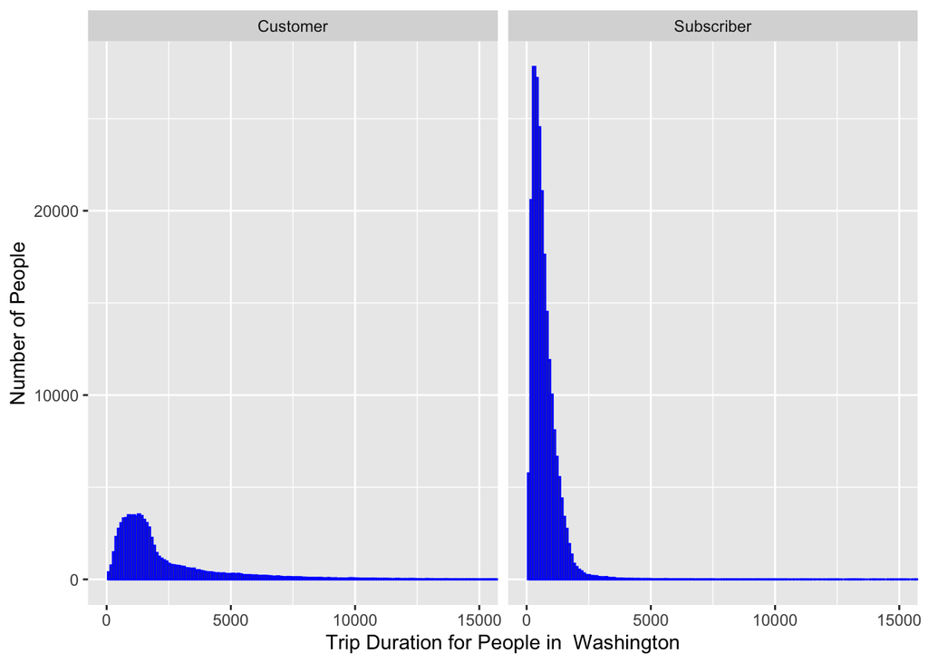

```r
#Washington
wash1=wash %>%        #Removing NA values for User Type in Washington
mutate_if(is.factor,trimws) %>%
filter(User.Type!='')

qplot(x=Trip.Duration, #Plotting User.Group Trip duration for Washington.
data=subset(wash1),
binwidth=100,
color=I('blue')) +
facet_wrap(~User.Type)+
coord_cartesian(xlim =c (0,15000))+
xlab('Trip Duration for People in  Washington') +
ylab('Number of People')
```

```r
by(wash1$Trip.Duration,wash1$User.Type,summary)
```

```
## wash1$User.Type: Customer
##      Min.   1st Qu.    Median      Mean   3rd Qu.      Max.
##      60.1     920.0    1492.2    2635.1    2717.4 1235662.2
## ------------------------------------------------------------
## wash1$User.Type: Subscriber
##     Min.  1st Qu.   Median     Mean  3rd Qu.     Max.
##     60.0    353.5    570.3    735.8    902.7 451434.9
```

```r
by(wash1$Trip.Duration,wash1$User.Type,sum)   #Getting Washington Trip Duration count
```

```
## wash1$User.Type: Customer
## [1] 208740308
## ------------------------------------------------------------
## wash1$User.Type: Subscriber
## [1] 162443678
```

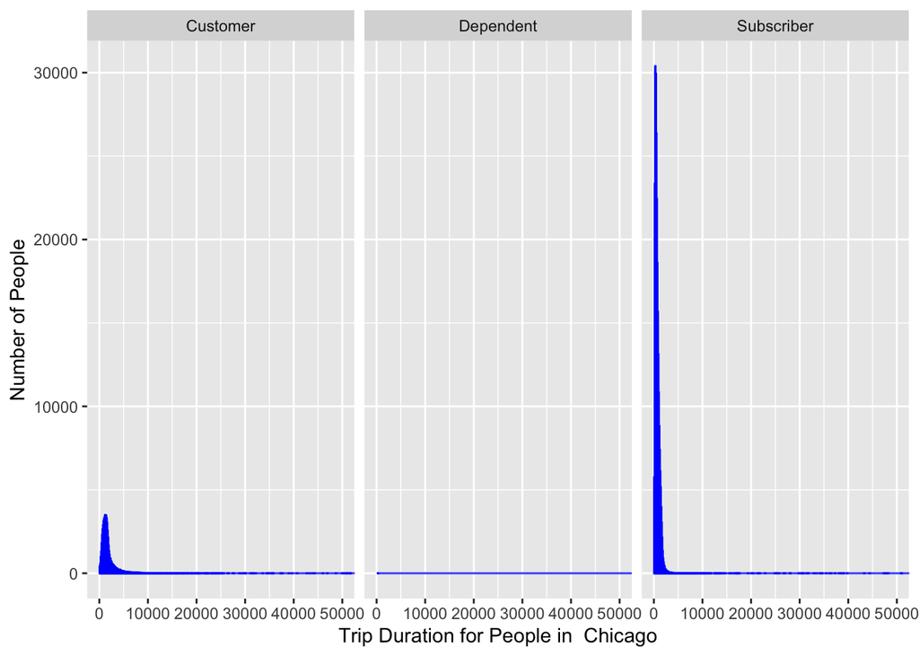

```r
#Chicago
chi1 =chi %>%     #Removing NA values for User Type in Chicago
mutate_if(is.factor,trimws) %>%
filter(User.Type!='')

qplot(x=Trip.Duration, #Plotting User.Group Trip duration for Chicago.
data=chi1,
binwidth=100,
color=I('blue')) +
facet_wrap(~User.Type)+
coord_cartesian(xlim =c (0,50000))+
xlab('Trip Duration for People in  Chicago') +
ylab('Number of People')
```

```r
by(chi1$Trip.Duration,chi1$User.Type,summary)
```

```
## chi1$User.Type: Customer
##    Min. 1st Qu.  Median    Mean 3rd Qu.    Max.
##    60.0   927.2  1380.0  1862.5  1960.0 86224.0
## ------------------------------------------------------------
## chi1$User.Type: Dependent
##    Min. 1st Qu.  Median    Mean 3rd Qu.    Max.
##     311     311     311     311     311     311
## ------------------------------------------------------------
## chi1$User.Type: Subscriber
##    Min. 1st Qu.  Median    Mean 3rd Qu.    Max.
##    60.0   351.0   565.0   699.3   899.0 85742.0
```

```r
by(chi1$Trip.Duration,chi1$User.Type,sum)   #Getting Chicago Trip Duration count
```

```
## chi1$User.Type: Customer
## [1] 113816825
## ------------------------------------------------------------
## chi1$User.Type: Dependent
## [1] 311
## ------------------------------------------------------------
## chi1$User.Type: Subscriber
## [1] 167054651
```

#NUMBER 1b ANSWERS SUMMARY #New York #Subcribers has a higher accumulated trip duration of 206864152 compared to Customer with an accumulated trip of #62021801 Just as the plot depicted. #Washington #Washington bike data,Customers have a higher accumlated trip duration of 208740308 compared to #subcribers accumulated trip duration of 162443678. #Chicago #Chicago bike data. Subcribers have a higher accumulated trip duration of 167054651 compared to customer and dependent #having an accumulated trip duration of 113816825 and 311 respectively.

#NUMBER 2 START STATION AND END STATION. #Plot and determine the start station and end station in each state that has the highest count.

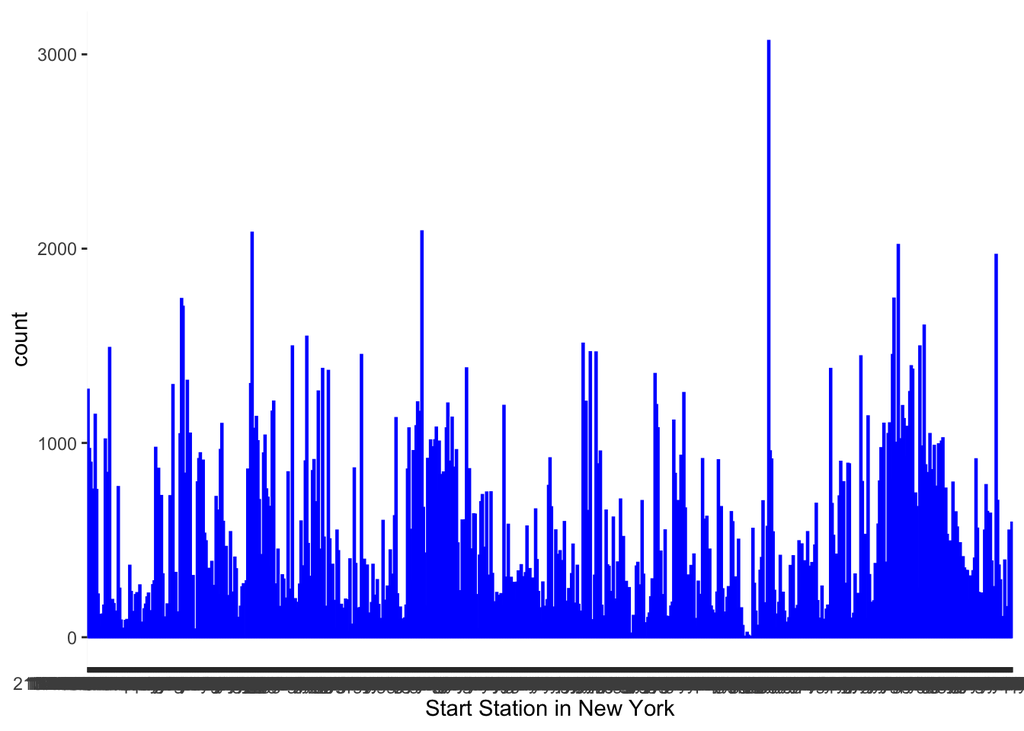

```r
#2a.Start Stations

#New York
qplot(x=Start.Station, #Plotting Start Station for New York.
data=subset(ny,!is.na(Start.Station)),
stat = ('count'),
color=I('blue')) +
xlab('Start Station in New York')+
ylab("count")
```

```r
ny %>%     #most popular start Station in New York.
count(Start.Station) %>%
filter(n==max(n))
```

```
## # A tibble: 1 x 2
##   Start.Station             n
##   <fct>                 <int>
## 1 Pershing Square North  3069
```

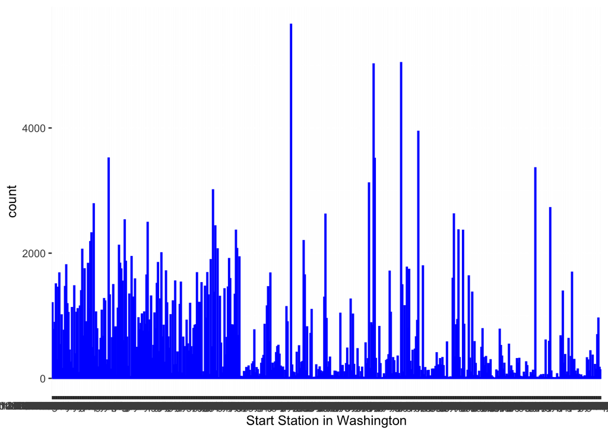

```r
#Washington
qplot(x=Start.Station, #Plotting Start Station for washington.
data=subset(wash,!is.na(Start.Station)),
stat = ('count'),
color=I('blue')) +
xlab('Start Station in Washington')+
ylab("count")
```

```r
wash %>%    #most popular start Station in Washington.
count(Start.Station) %>%
filter(n==max(n))
```

```
## # A tibble: 1 x 2
##   Start.Station                       n
##   <fct>                           <int>
## 1 Columbus Circle / Union Station  5656
```

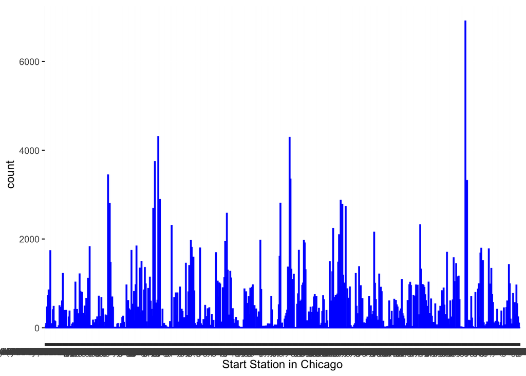

```r
#Chicago
qplot(x=Start.Station, #Plotting Start Station for Chicago.
data=subset(chi,!is.na(Start.Station)),
stat = ('count'),
color=I('blue')) +
xlab('Start Station in Chicago')+
ylab("count")
```

```r
chi%>%
count(Start.Station) %>%     #most popular start Station in Chicago.
filter(n==max(n))
```

```
## # A tibble: 1 x 2
##   Start.Station               n
##   <fct>                   <int>
## 1 Streeter Dr & Grand Ave  6911
```

#NUMBER 2a ANSWER SUMMARY #The most used start station in New York is Pershing Square North with a count of 3069 as shown in the plot. #The most used start station in Washington is Columbus Circle/Union Station with a count of 5656 as shown in the plot. #The most used start station in Chicago is Streeter Dr and Grand Ave with a count of 6911 as shown in the plot.

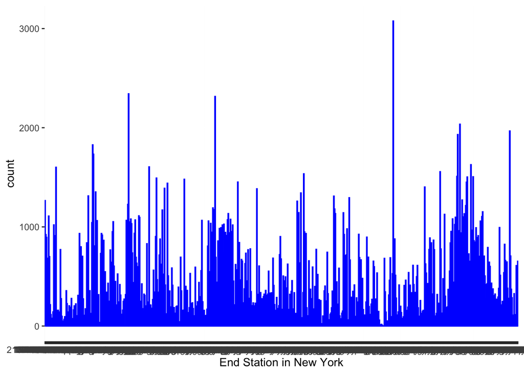

```r
#2b End Stations

#New York
qplot(x=End.Station, #Plotting Start Station for New York.
data=subset(ny,!is.na(End.Station)),
stat = ('count'),
color=I('blue')) +
xlab('End Station in New York')+
ylab("count")
```

```r
ny %>%     #most popular End Station in New York.
count(End.Station) %>%
filter(n==max(n))
```

```
## # A tibble: 1 x 2
##   End.Station               n
##   <fct>                 <int>
## 1 Pershing Square North  3077
```

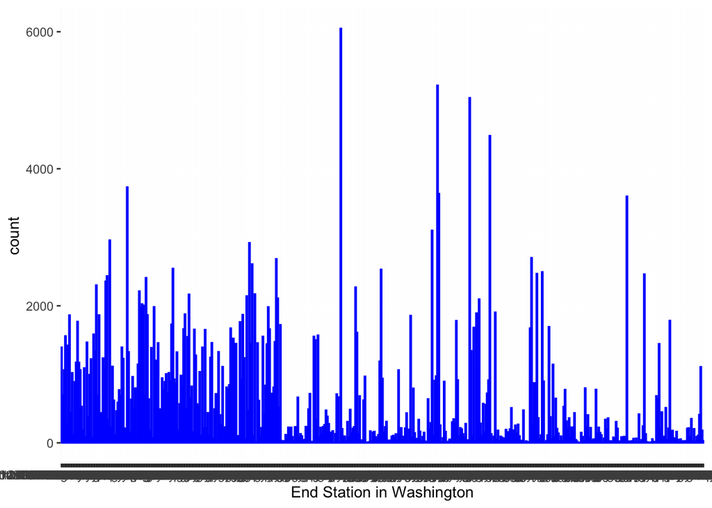

```r
#Washington
qplot(x=End.Station, #Plotting Start Station for washington.
data=subset(wash,!is.na(End.Station)),
stat = ('count'),
color=I('blue')) +
xlab('End Station in Washington')+
ylab("count")
```

```r
wash %>%    #most popular end Station in Washington.
count(End.Station) %>%
filter(n==max(n))
```

```
## # A tibble: 1 x 2
##   End.Station                         n
##   <fct>                           <int>
## 1 Columbus Circle / Union Station  6048
```

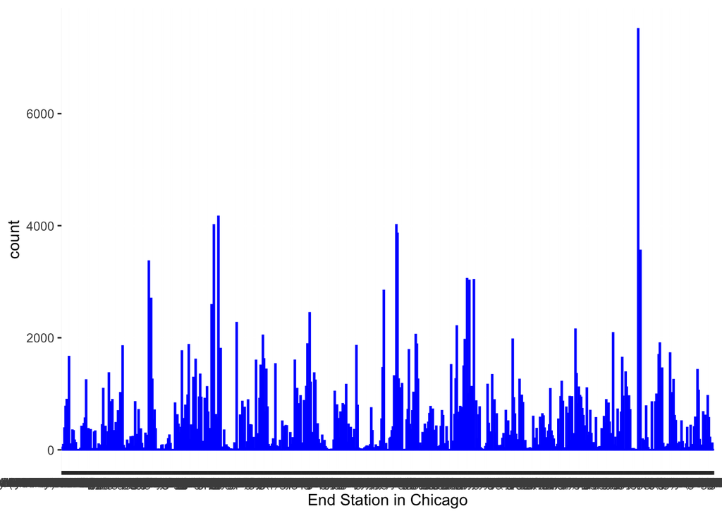

```r
#Chicago
qplot(x=End.Station, #Plotting Start Station for washington.
data=subset(chi,!is.na(End.Station)),
stat = ('count'),
color=I('blue')) +
xlab('End Station in Chicago')+
ylab("count")
```

```r
chi %>%    #most popular end Station in Chicago.
count(End.Station) %>%
filter(n==max(n))
```

```
## # A tibble: 1 x 2
##   End.Station                 n
##   <fct>                   <int>
## 1 Streeter Dr & Grand Ave  7512
```

#NUMBER 3 START TIME AND END TIME #Plot and determine the most month and day that occurs mostly in the start time and end time of the three cities?

```r
#3a Start time month and Day of the week
#New York
#New York Start time Month
ny=ny %>%       #mutating the start time
mutate(Start.Time=ymd_hms(Start.Time))
head(ny)
```

```
##         X          Start.Time            End.Time Trip.Duration
## 1 5688089 2017-06-11 14:55:05 2017-06-11 15:08:21           795
## 2 4096714 2017-05-11 15:30:11 2017-05-11 15:41:43           692
## 3 2173887 2017-03-29 13:26:26 2017-03-29 13:48:31          1325
## 4 3945638 2017-05-08 19:47:18 2017-05-08 19:59:01           703
## 5 6208972 2017-06-21 07:49:16 2017-06-21 07:54:46           329
## 6 1285652 2017-02-22 18:55:24 2017-02-22 19:12:03           998
##             Start.Station            End.Station  User.Type Gender Birth.Year
## 1 Suffolk St & Stanton St W Broadway & Spring St Subscriber   Male       1998
## 2 Lexington Ave & E 63 St        1 Ave & E 78 St Subscriber   Male       1981
## 3       1 Pl & Clinton St   Henry St & Degraw St Subscriber   Male       1987
## 4   Barrow St & Hudson St        W 20 St & 8 Ave Subscriber Female       1986
## 5         1 Ave & E 44 St        E 53 St & 3 Ave Subscriber   Male       1992
## 6     State St & Smith St    Bond St & Fulton St Subscriber   Male       1986
```

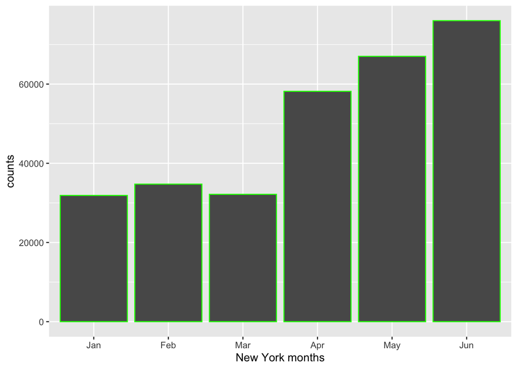

```r
ny=ny %>%       #mutating the start time and dividing by month
mutate(month.name=month(Start.Time,
label = TRUE))

qplot(x=month.name,     #Plotting the months in the start time against counts
data=ny,
color=I('green'))+
xlab('New York months')+
ylab('counts')
```

```r
ny %>%        #Getting the month with the highest count
count(month.name) %>%
filter(n==max(n))
```

```
## # A tibble: 1 x 2
##   month.name     n
##   <ord>      <int>
## 1 Jun        76022
```

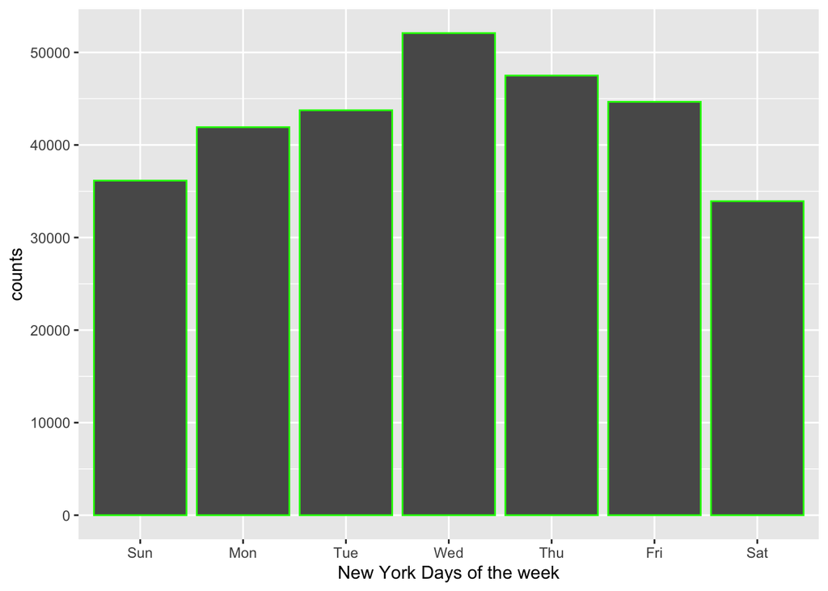

```r
#New York Start time Day of the week
ny=ny%>%      #mutating the start time and dividing by day of the week
mutate(day_week=wday(Start.Time,
label = TRUE))

qplot(x=day_week,    #Plotting the days of the week in the start time against counts
data=ny,
color=I('green')) +
xlab('New York Days of the week')+
ylab('counts')
```

```r
ny %>%        #Getting the day of the week with the highest count
count(day_week) %>%
filter(n==max(n))
```

```
## # A tibble: 1 x 2
##   day_week     n
##   <ord>    <int>
## 1 Wed      52087
```

```r
#Washington
#NWashington Start time Month
wash=wash %>%       #mutating the start time
mutate(Start.Time=ymd_hms(Start.Time),
End.Time=ymd_hms(End.Time))
head(wash)
```

```
##         X          Start.Time            End.Time Trip.Duration
## 1 1621326 2017-06-21 08:36:34 2017-06-21 08:44:43       489.066
## 2  482740 2017-03-11 10:40:00 2017-03-11 10:46:00       402.549
## 3 1330037 2017-05-30 01:02:59 2017-05-30 01:13:37       637.251
## 4  665458 2017-04-02 07:48:35 2017-04-02 08:19:03      1827.341
## 5 1481135 2017-06-10 08:36:28 2017-06-10 09:02:17      1549.427
## 6 1148202 2017-05-14 07:18:18 2017-05-14 07:24:56       398.000
##                                 Start.Station
## 1                        14th & Belmont St NW
## 2                  Yuma St & Tenley Circle NW
## 3              17th St & Massachusetts Ave NW
## 4            Constitution Ave & 2nd St NW/DOL
## 5 Henry Bacon Dr & Lincoln Memorial Circle NW
## 6                               1st & K St SE
##                                           End.Station  User.Type
## 1                                      15th & K St NW Subscriber
## 2                        Connecticut Ave & Yuma St NW Subscriber
## 3                                       5th & K St NW Subscriber
## 4                          M St & Pennsylvania Ave NW   Customer
## 5                               Maine Ave & 7th St SW Subscriber
## 6 Eastern Market Metro / Pennsylvania Ave & 7th St SE Subscriber
```

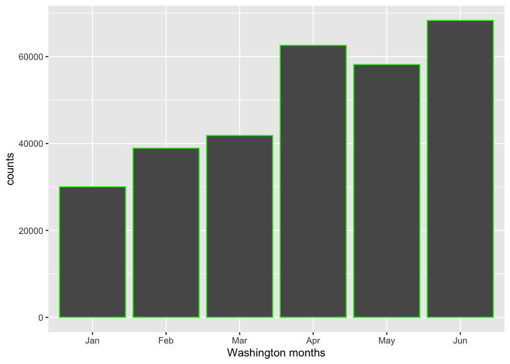

```r
wash=wash %>%       #mutating the start time and dividing by month
mutate(month.name=month(Start.Time,
label = TRUE))

qplot(x=month.name,     #Plotting the months in the start time against counts
data=wash,
color=I('green'))+
xlab('Washington months')+
ylab('counts')
```

```r
wash %>%        #Getting the month with the highest count
count(month.name) %>%
filter(n==max(n))
```

```
## # A tibble: 1 x 2
##   month.name     n
##   <ord>      <int>
## 1 Jun        68339
```

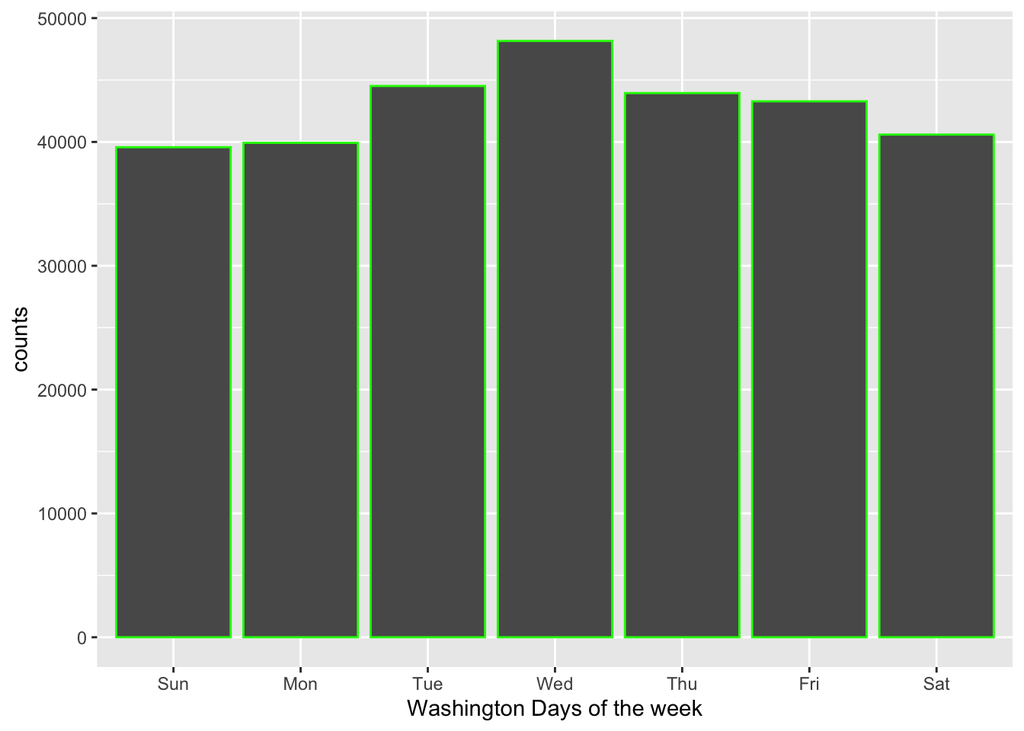

```r
#Washington Start time Day of the week
wash=wash%>%      #mutating the start time and dividing by day of the week
mutate(day_week=wday(Start.Time,
label = TRUE))

qplot(x=day_week,    #Plotting the days of the week in the start time against counts
data=wash,
color=I('green')) +
xlab('Washington Days of the week')+
ylab('counts')
```

```r
wash %>%        #Getting the day of the week with the highest count
count(day_week) %>%
filter(n==max(n))
```

```
## # A tibble: 1 x 2
##   day_week     n
##   <ord>    <int>
## 1 Wed      48156
```

```r
#Chicago
#Chicago Start time Month
chi=chi %>%       #mutating the start time
mutate(Start.Time=ymd_hms(Start.Time),
End.Time=ymd_hms(End.Time))
head(chi)
```

```
##         X          Start.Time            End.Time Trip.Duration
## 1 1423854 2017-06-23 15:09:32 2017-06-23 15:14:53           321
## 2  955915 2017-05-25 18:19:03 2017-05-25 18:45:53          1610
## 3    9031 2017-01-04 08:27:49 2017-01-04 08:34:45           416
## 4  304487 2017-03-06 13:49:38 2017-03-06 13:55:28           350
## 5   45207 2017-01-17 14:53:07 2017-01-17 15:02:01           534
## 6 1473887 2017-06-26 09:01:20 2017-06-26 09:11:06           586
##                   Start.Station                  End.Station  User.Type Gender
## 1          Wood St & Hubbard St      Damen Ave & Chicago Ave Subscriber   Male
## 2           Theater on the Lake Sheffield Ave & Waveland Ave Subscriber Female
## 3            May St & Taylor St          Wood St & Taylor St Subscriber   Male
## 4 Christiana Ave & Lawrence Ave St. Louis Ave & Balmoral Ave Subscriber   Male
## 5        Clark St & Randolph St Desplaines St & Jackson Blvd Subscriber   Male
## 6  Clinton St & Washington Blvd         Canal St & Taylor St Subscriber   Male
##   Birth.Year
## 1       1992
## 2       1992
## 3       1981
## 4       1986
## 5       1975
## 6       1990
```

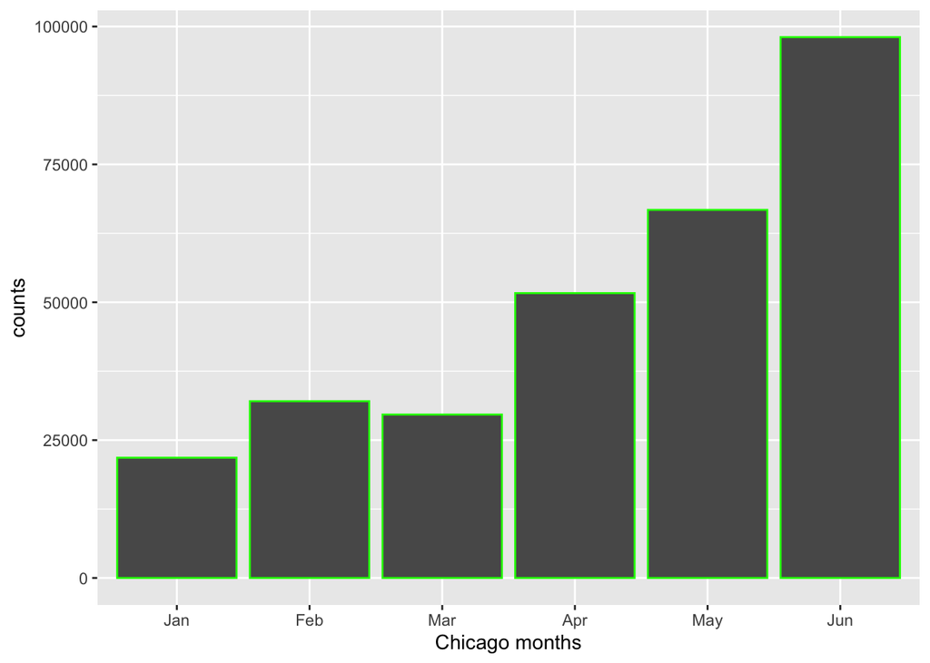

```r
chi=chi %>%       #mutating the start time and dividing by month
mutate(month.name=month(Start.Time,
label = TRUE))

qplot(x=month.name,     #Plotting the months in the start time against counts
data=chi,
color=I('green'))+
xlab('Chicago months')+
ylab('counts')
```

```r
chi %>%        #Getting the month with the highest count
count(month.name) %>%
filter(n==max(n))
```

```
## # A tibble: 1 x 2
##   month.name     n
##   <ord>      <int>
## 1 Jun        98081
```

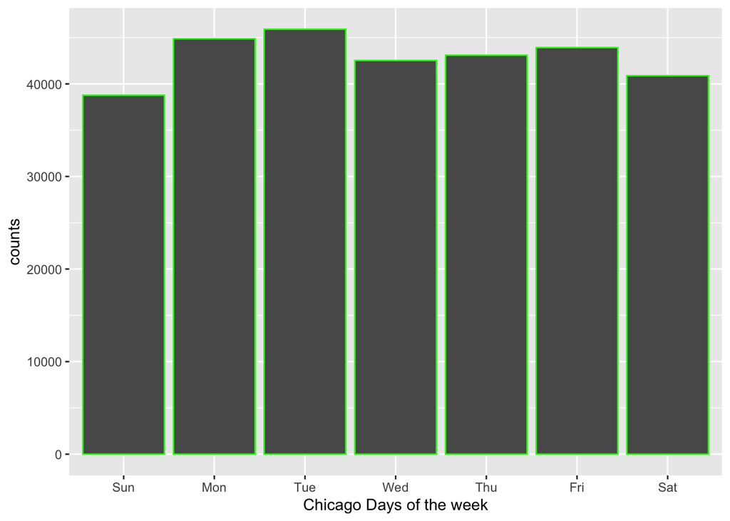

```r
#Chicago Start time Day of the week
chi=chi%>%      #mutating the start time and dividing by day of the week
mutate(day_week=wday(Start.Time,
label = TRUE))

qplot(x=day_week,    #Plotting the days of the week in the start time against counts
data=chi,
color=I('green')) +
xlab('Chicago Days of the week')+
ylab('counts')
```

```r
chi %>%        #Getting the day of the week with the highest count
count(day_week) %>%
filter(n==max(n))
```

```
## # A tibble: 1 x 2
##   day_week     n
##   <ord>    <int>
## 1 Tue      45912
```

#NUMBER 3a ANSWER SUMMARY # New York start time most populous month is June with a count of 76022. # New York start time most populous day of the week is Wednesday with a count of 52087. # Washington start time most populous month is June with a count of 68339. # Washington start time most populous day of the week is Wednesday with a count of 48156. # Chicago start time most populous month is June with a count of 98081. # Chicago start time most populous day of the week is Tuesday with a count of 45912.

```r
#3b End time month and Day of the week
#End Time
#New York End Time
ny=ny %>%       #mutating the end time
mutate(End.Time=ymd_hms(End.Time))
head(ny)
```

```
##         X          Start.Time            End.Time Trip.Duration
## 1 5688089 2017-06-11 14:55:05 2017-06-11 15:08:21           795
## 2 4096714 2017-05-11 15:30:11 2017-05-11 15:41:43           692
## 3 2173887 2017-03-29 13:26:26 2017-03-29 13:48:31          1325
## 4 3945638 2017-05-08 19:47:18 2017-05-08 19:59:01           703
## 5 6208972 2017-06-21 07:49:16 2017-06-21 07:54:46           329
## 6 1285652 2017-02-22 18:55:24 2017-02-22 19:12:03           998
##             Start.Station            End.Station  User.Type Gender Birth.Year
## 1 Suffolk St & Stanton St W Broadway & Spring St Subscriber   Male       1998
## 2 Lexington Ave & E 63 St        1 Ave & E 78 St Subscriber   Male       1981
## 3       1 Pl & Clinton St   Henry St & Degraw St Subscriber   Male       1987
## 4   Barrow St & Hudson St        W 20 St & 8 Ave Subscriber Female       1986
## 5         1 Ave & E 44 St        E 53 St & 3 Ave Subscriber   Male       1992
## 6     State St & Smith St    Bond St & Fulton St Subscriber   Male       1986
##   month.name day_week
## 1        Jun      Sun
## 2        May      Thu
## 3        Mar      Wed
## 4        May      Mon
## 5        Jun      Wed
## 6        Feb      Wed
```

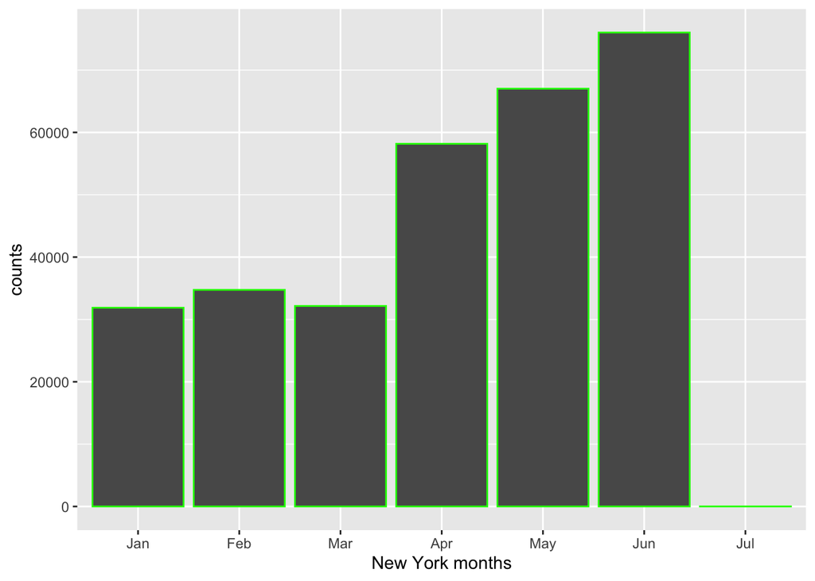

```r
ny=ny %>%       #mutating the end time and dividing by month
mutate(month.name=month(End.Time,
label = TRUE))

qplot(x=month.name,     #Plotting the months in the end time against counts
data=ny,
color=I('green'))+
xlab('New York months')+
ylab('counts')
```

```r
ny %>%        #Getting the month with the highest count
count(month.name) %>%
filter(n==max(n))
```

```
## # A tibble: 1 x 2
##   month.name     n
##   <ord>      <int>
## 1 Jun        76019
```

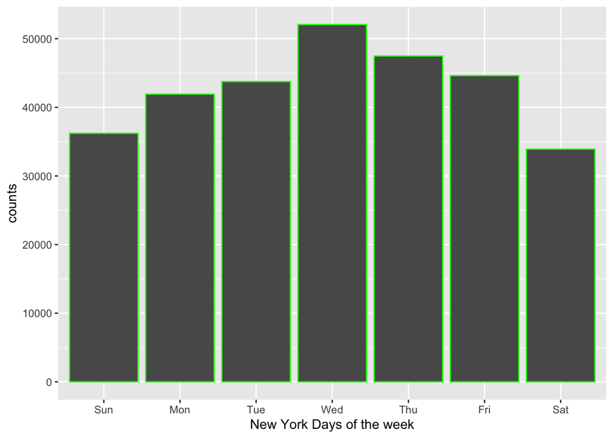

```r
#New York Start time Day of the week
ny=ny%>%      #mutating the end time and dividing by day of the week
mutate(day_week=wday(End.Time,
label = TRUE))

qplot(x=day_week,    #Plotting the days of the week in the end time against counts
data=ny,
color=I('green')) +
xlab('New York Days of the week')+
ylab('counts')
```

```r
ny %>%        #Getting the day of the week with the highest count
count(day_week) %>%
filter(n==max(n))
```

```
## # A tibble: 1 x 2
##   day_week     n
##   <ord>    <int>
## 1 Wed      52070
```

```r
#Washington
#NWashington End time Month
wash=wash %>%       #mutating the end time
mutate(Start.Time=ymd_hms(Start.Time),
End.Time=ymd_hms(End.Time))
head(wash)
```

```
##         X          Start.Time            End.Time Trip.Duration
## 1 1621326 2017-06-21 08:36:34 2017-06-21 08:44:43       489.066
## 2  482740 2017-03-11 10:40:00 2017-03-11 10:46:00       402.549
## 3 1330037 2017-05-30 01:02:59 2017-05-30 01:13:37       637.251
## 4  665458 2017-04-02 07:48:35 2017-04-02 08:19:03      1827.341
## 5 1481135 2017-06-10 08:36:28 2017-06-10 09:02:17      1549.427
## 6 1148202 2017-05-14 07:18:18 2017-05-14 07:24:56       398.000
##                                 Start.Station
## 1                        14th & Belmont St NW
## 2                  Yuma St & Tenley Circle NW
## 3              17th St & Massachusetts Ave NW
## 4            Constitution Ave & 2nd St NW/DOL
## 5 Henry Bacon Dr & Lincoln Memorial Circle NW
## 6                               1st & K St SE
##                                           End.Station  User.Type month.name
## 1                                      15th & K St NW Subscriber        Jun
## 2                        Connecticut Ave & Yuma St NW Subscriber        Mar
## 3                                       5th & K St NW Subscriber        May
## 4                          M St & Pennsylvania Ave NW   Customer        Apr
## 5                               Maine Ave & 7th St SW Subscriber        Jun
## 6 Eastern Market Metro / Pennsylvania Ave & 7th St SE Subscriber        May
##   day_week
## 1      Wed
## 2      Sat
## 3      Tue
## 4      Sun
## 5      Sat
## 6      Sun
```

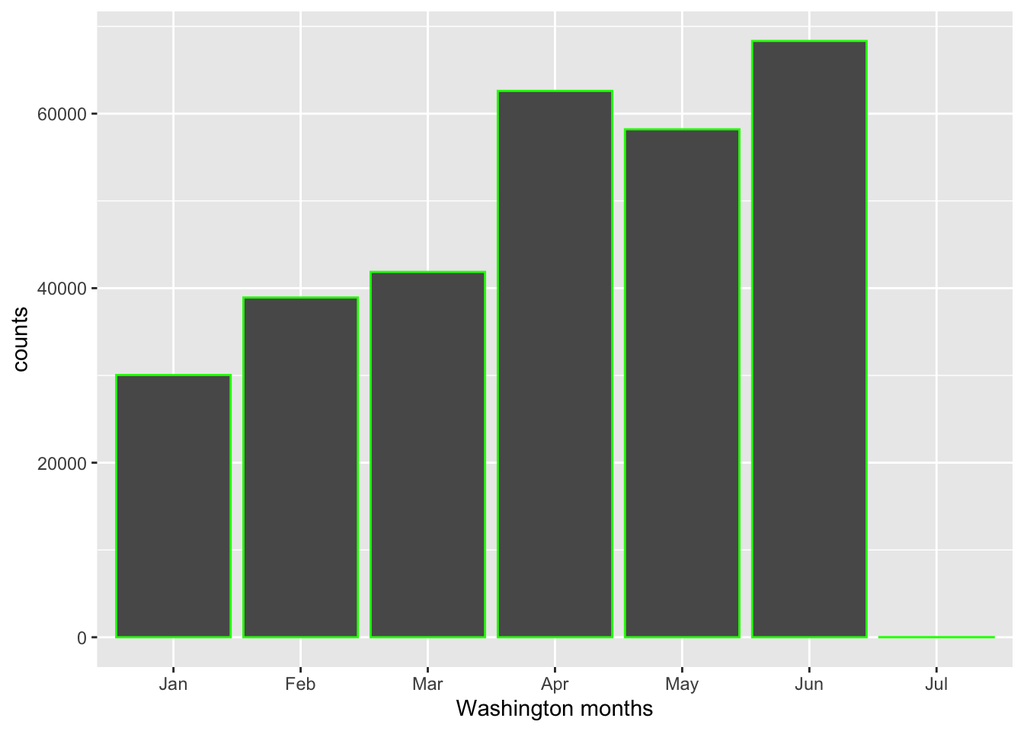

```r
wash=wash %>%       #mutating the end time and dividing by month
mutate(month.name=month(End.Time,
label = TRUE))

qplot(x=month.name,     #Plotting the months in the end time against counts
data=wash,
color=I('green'))+
xlab('Washington months')+
ylab('counts')
```

```r
wash %>%        #Getting the month with the highest count
count(month.name) %>%
filter(n==max(n))
```

```
## # A tibble: 1 x 2
##   month.name     n
##   <ord>      <int>
## 1 Jun        68329
```

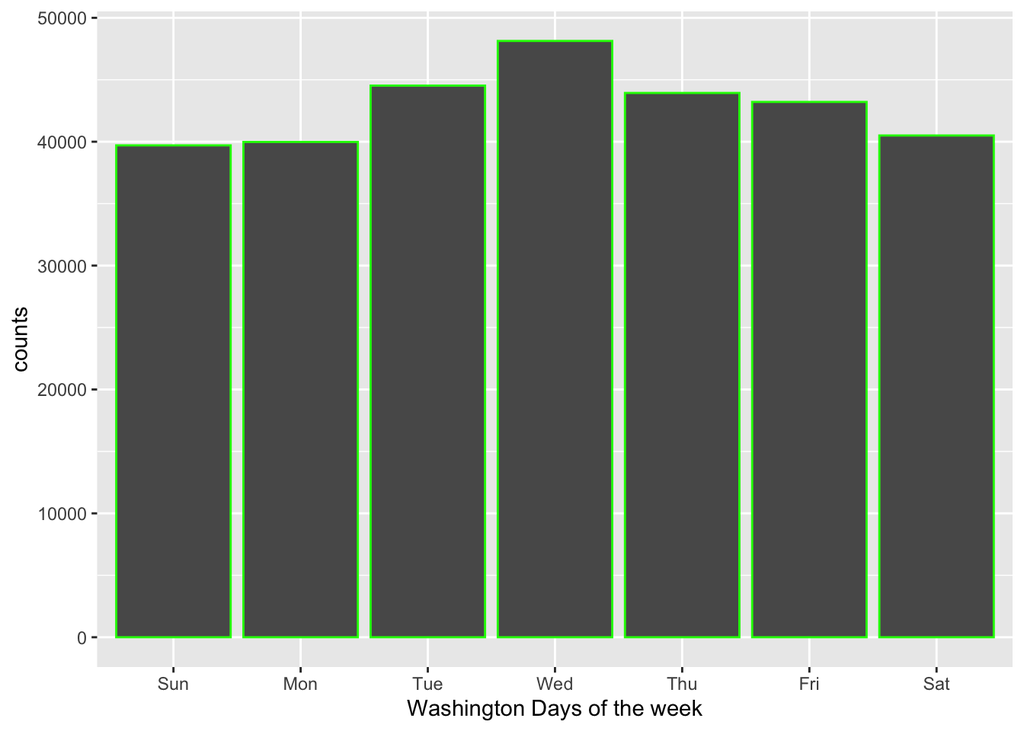

```r
#Washington Start time Day of the week
wash=wash%>%      #mutating the end time and dividing by day of the week
mutate(day_week=wday(End.Time,
label = TRUE))

qplot(x=day_week,    #Plotting the days of the week in the end time against counts
data=wash,
color=I('green')) +
xlab('Washington Days of the week')+
ylab('counts')
```

```r
wash %>%        #Getting the day of the week with the highest count
count(day_week) %>%
filter(n==max(n))
```

```
## # A tibble: 1 x 2
##   day_week     n
##   <ord>    <int>
## 1 Wed      48134
```

```r
#Chicago
#Chicago End time Month
chi=chi %>%       #mutating the end time
mutate(Start.Time=ymd_hms(Start.Time),
End.Time=ymd_hms(End.Time))
head(chi)
```

```
##         X          Start.Time            End.Time Trip.Duration
## 1 1423854 2017-06-23 15:09:32 2017-06-23 15:14:53           321
## 2  955915 2017-05-25 18:19:03 2017-05-25 18:45:53          1610
## 3    9031 2017-01-04 08:27:49 2017-01-04 08:34:45           416
## 4  304487 2017-03-06 13:49:38 2017-03-06 13:55:28           350
## 5   45207 2017-01-17 14:53:07 2017-01-17 15:02:01           534
## 6 1473887 2017-06-26 09:01:20 2017-06-26 09:11:06           586
##                   Start.Station                  End.Station  User.Type Gender
## 1          Wood St & Hubbard St      Damen Ave & Chicago Ave Subscriber   Male
## 2           Theater on the Lake Sheffield Ave & Waveland Ave Subscriber Female
## 3            May St & Taylor St          Wood St & Taylor St Subscriber   Male
## 4 Christiana Ave & Lawrence Ave St. Louis Ave & Balmoral Ave Subscriber   Male
## 5        Clark St & Randolph St Desplaines St & Jackson Blvd Subscriber   Male
## 6  Clinton St & Washington Blvd         Canal St & Taylor St Subscriber   Male
##   Birth.Year month.name day_week
## 1       1992        Jun      Fri
## 2       1992        May      Thu
## 3       1981        Jan      Wed
## 4       1986        Mar      Mon
## 5       1975        Jan      Tue
## 6       1990        Jun      Mon
```

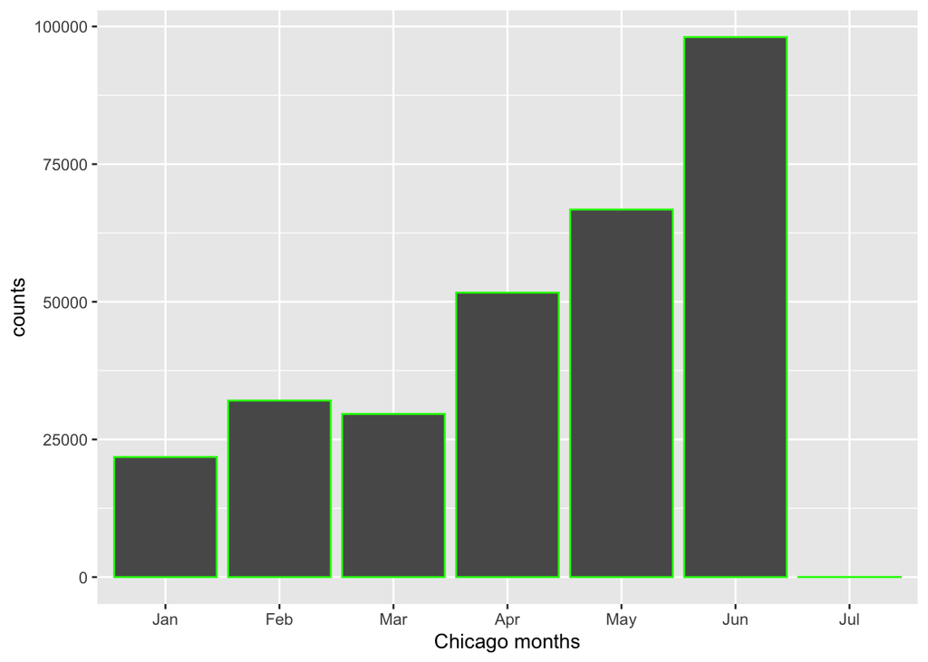

```r
chi=chi %>%       #mutating the end time and dividing by month
mutate(month.name=month(End.Time,
label = TRUE))

qplot(x=month.name,     #Plotting the months in the start time against counts
data=chi,
color=I('green'))+
xlab('Chicago months')+
ylab('counts')
```

```r
chi %>%        #Getting the month with the highest count
count(month.name) %>%
filter(n==max(n))
```

```
## # A tibble: 1 x 2
##   month.name     n
##   <ord>      <int>
## 1 Jun        98074
```

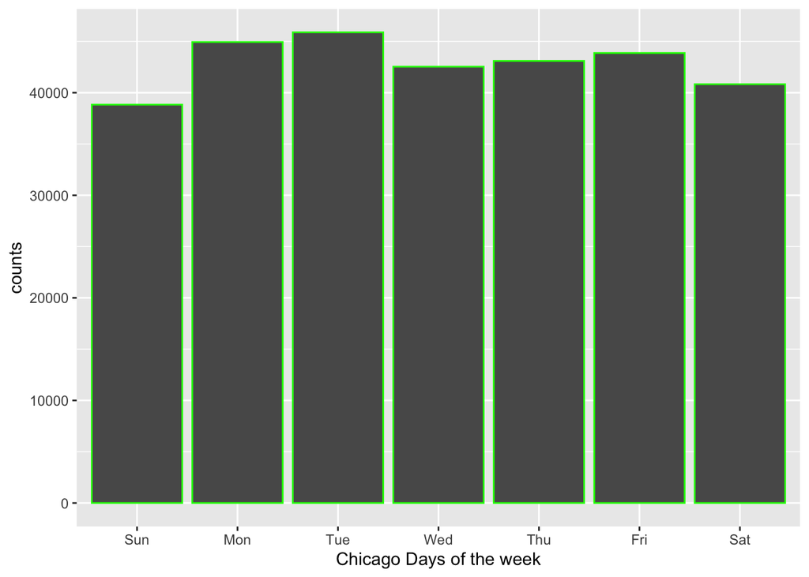

```r
#Chicago End time Day of the week
chi=chi%>%      #mutating the end time and dividing by day of the week
mutate(day_week=wday(End.Time,
label = TRUE))

qplot(x=day_week,    #Plotting the days of the week in the end time against counts
data=chi,
color=I('green')) +
xlab('Chicago Days of the week')+
ylab('counts')
```

```r
chi %>%        #Getting the day of the week with the highest count
count(day_week) %>%
filter(n==max(n))
```

```
## # A tibble: 1 x 2
##   day_week     n
##   <ord>    <int>
## 1 Tue      45887
```

#NUMBER 3b ANSWER SUMMARY # New York end time most populous month is June with a count of 76019. # New York end time most populous day of the week is Wednesday with a count of 52070. # Washington end time most populous month is June with a count of 68329. # Washington end time most populous day of the week is Wednesday with a count of 48134. # Chicago end time most populous month is June with a count of 98074. # Chicago start time most populous day of the week is Tuesday with a count of 45887.